# PEC3

Diego Vallarino

2/6/2021

# 1 Preparacion y Analisis de la Data

## 1.1 Cargar los Datos

```r
library(knitr)
library(readxl)
library(ggplot2)
library(caret)
data_edit <- read_excel("./data_edit.xlsx")
data_edit$class <- data_edit$Column10
data_edit<-data_edit[,-9]
data<-data_edit
data$class<-as.factor(data$class)
```

**NOTA**: Es relevante aclarar que el proceso de cierto manejo de datos, como por ejemplo, la transformacion de ME1, ME2 y ME3 a MEM, se realizó en otro software diferente a *R*. El output en este caso dio un archivo en excel que es el que se utiliza para realizar el analisis. Si bien esto pasa habitualmente en la industria (utilizar la herramienta más eficiente para la tarea necesaria) en este caso limitó mucho el dinamismo del documento. Lo que se puede indetificar como una debilidad del presente trabajo (el cual el autor se hace responsable)

## 1.2 Analisis de los Datos

```r
str(data)
```

```
## tibble [1,394 x 9] (S3: tbl_df/tbl/data.frame)
##  $ Column2: num [1:1394] 58 43 64 58 42 51 50 48 55 40 ...
##  $ Column3: num [1:1394] 61 67 62 44 44 40 54 45 50 39 ...
##  $ Column4: num [1:1394] 47 48 49 57 48 56 48 59 66 60 ...
##  $ Column5: num [1:1394] 13 27 15 13 54 17 65 20 36 15 ...
##  $ Column6: num [1:1394] 50 50 50 50 50 50 50 50 50 50 ...
##  $ Column7: num [1:1394] 0 0 0 0 0 50 0 0 0 0 ...
##  $ Column8: num [1:1394] 48 53 53 54 48 49 53 58 49 58 ...
##  $ Column9: num [1:1394] 22 22 22 22 22 22 22 34 22 30 ...
##  $ class  : Factor w/ 4 levels "CYT","MEM","MIT",..: 3 3 3 4 3 1 3 4 3 1 ...
```

```r
table(data$class)
```

```
##
## CYT MEM MIT NUC
## 463 258 244 429
```

```r
summary(data)
```

```
##     Column2          Column3          Column4          Column5
##  Min.   : 11.00   Min.   : 13.00   Min.   : 21.00   Min.   :  0.00
##  1st Qu.: 40.00   1st Qu.: 42.00   1st Qu.: 46.00   1st Qu.: 17.00
##  Median : 48.00   Median : 48.00   Median : 51.00   Median : 22.00
##  Mean   : 49.18   Mean   : 49.28   Mean   : 50.09   Mean   : 26.16
##  3rd Qu.: 57.00   3rd Qu.: 56.00   3rd Qu.: 56.00   3rd Qu.: 32.00
##  Max.   :100.00   Max.   :100.00   Max.   :100.00   Max.   :100.00
##     Column6          Column7           Column8         Column9       class
##  Min.   : 50.00   Min.   : 0.0000   Min.   : 0.00   Min.   :  0.00   CYT:463
##  1st Qu.: 50.00   1st Qu.: 0.0000   1st Qu.:48.00   1st Qu.: 22.00   MEM:258
##  Median : 50.00   Median : 0.0000   Median :51.00   Median : 22.00   MIT:244
##  Mean   : 50.32   Mean   : 0.1908   Mean   :50.02   Mean   : 27.87   NUC:429
##  3rd Qu.: 50.00   3rd Qu.: 0.0000   3rd Qu.:53.00   3rd Qu.: 31.00
##  Max.   :100.00   Max.   :83.0000   Max.   :73.00   Max.   :100.00
```

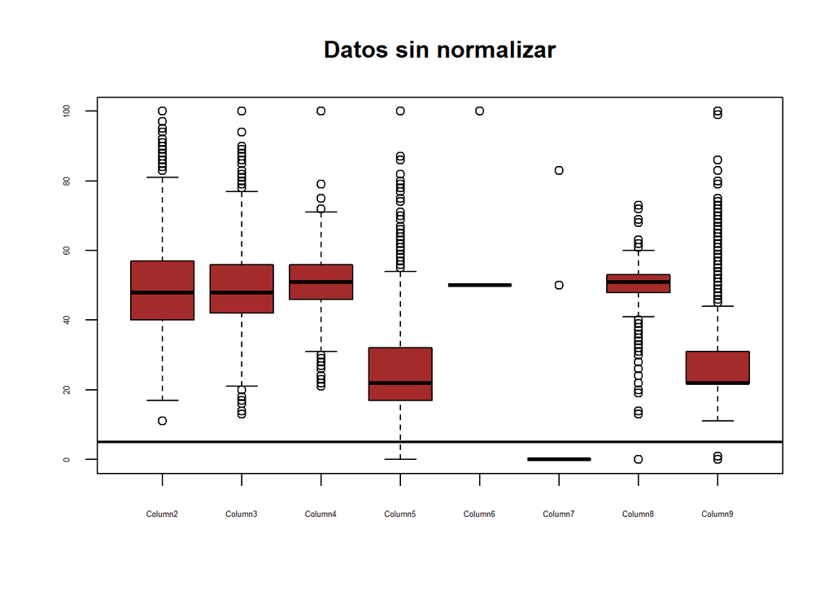

```r
boxplot(data[,1:8],main='Datos sin normalizar',col='brown',cex.axis=0.4,subset=data$class)
abline(h=5,lwd=2)
```

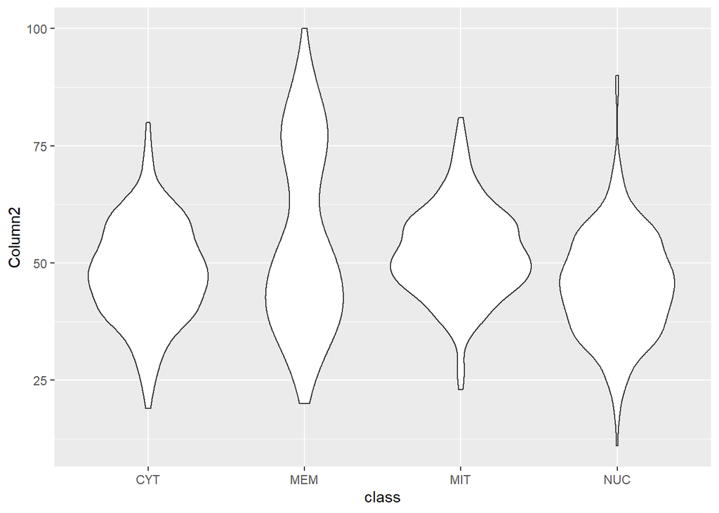

```r
plot <- ggplot(data, aes(x=class, y= Column2))
plot + geom_violin()
```

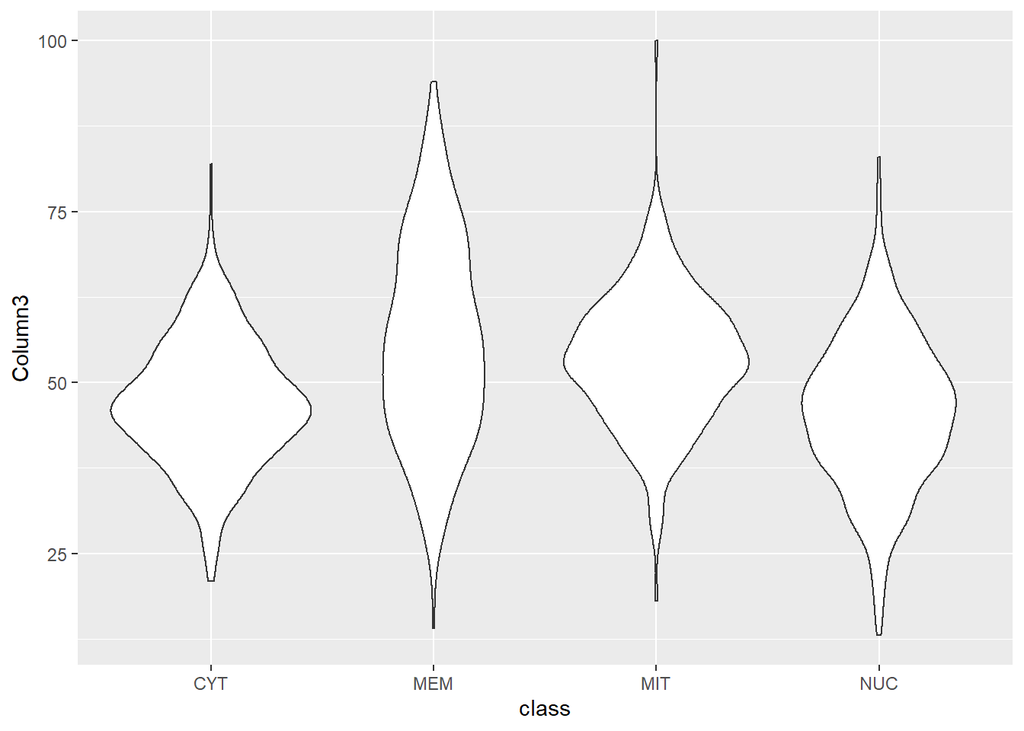

```r
plot <- ggplot(data, aes(x=class, y= Column3))
plot + geom_violin()
```

## 1.3 Preparacion de los datos (train - test)

```r
library(dplyr)
set.seed(params$seed.train)
data.test<-data[params$ind_test,]
data.train<-data[params$ind_train,]
```

### 1.3.1 Preparacion de los datos Normalizados

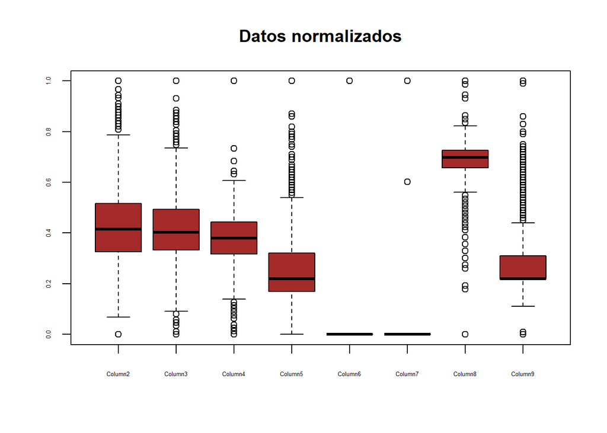

```r
normalize <- function(x) {return ((x - min(x)) / (max(x) - min(x)))}
data_n<-as.data.frame(lapply(data[1:8], normalize))
data.test.n<-data_n[params$ind_test,]
data.train.n<-data_n[params$ind_train,]
boxplot(data_n[,1:8],main='Datos normalizados',col='brown',cex.axis=0.4,subset=data$class)
abline(h=5,lwd=2)
```

# 2 Desarrollo de los Modelos

## 2.1 Modelo KNN

```r
library(class)
library(gmodels)
data$class<-as.factor(data$class)
data.test$class<-as.factor(data.test$class)
data.train$class<-as.factor(data.train$class)
knn_train_labels <- data[params$ind_train, 9]
knn_test_labels <- data[params$ind_test, 9]
knn_train_labels<-pull(knn_train_labels)

knn_test_pred <- knn(train = data.train.n, test = data.test.n, cl = knn_train_labels, k = 15)
knn_test_pred<-as.factor(knn_test_pred)
```

### 2.1.1 Evaluacion KNN

```r
matrizknn<-confusionMatrix(knn_test_pred, data.test$class)
matrizknn
```

```
## Confusion Matrix and Statistics
##
##           Reference
## Prediction CYT MEM MIT NUC
##        CYT 100   6  22  48
##        MEM   4  74  10   2
##        MIT  10   3  60  10
##        NUC  42   4   3  62
##
## Overall Statistics
##
##                Accuracy : 0.6435
##                  95% CI : (0.5978, 0.6873)
##     No Information Rate : 0.3391
##     P-Value [Acc > NIR] : < 2e-16
##
##                   Kappa : 0.5129
##
##  Mcnemar's Test P-Value : 0.03568
##
## Statistics by Class:
##
##                      Class: CYT Class: MEM Class: MIT Class: NUC
## Sensitivity              0.6410     0.8506     0.6316     0.5082
## Specificity              0.7500     0.9571     0.9370     0.8550
## Pos Pred Value           0.5682     0.8222     0.7229     0.5586
## Neg Pred Value           0.8028     0.9649     0.9072     0.8281
## Prevalence               0.3391     0.1891     0.2065     0.2652
## Detection Rate           0.2174     0.1609     0.1304     0.1348
## Detection Prevalence     0.3826     0.1957     0.1804     0.2413
## Balanced Accuracy        0.6955     0.9038     0.7843     0.6816
```

## 2.2 Naive Bayes

```r
data$class<-as.factor(data$class)
library(e1071)
modelo<-naiveBayes(class~., data = data.train, laplace=0)
modelo_pred<-predict(modelo, data.test)
data.test$class<-as.factor(data.test$class)
```

### 2.2.1 Evaluacion Naive Bayes

```r
matriznb<-confusionMatrix(modelo_pred, data.test$class)
matriznb
```

```
## Confusion Matrix and Statistics
##
##           Reference
## Prediction CYT MEM MIT NUC
##        CYT  77   1  22  42
##        MEM   8  75  13   3
##        MIT   8   2  56  10
##        NUC  63   9   4  67
##
## Overall Statistics
##
##                Accuracy : 0.5978
##                  95% CI : (0.5514, 0.643)
##     No Information Rate : 0.3391
##     P-Value [Acc > NIR] : < 2.2e-16
##
##                   Kappa : 0.4551
##
##  Mcnemar's Test P-Value : 4.261e-05
##
## Statistics by Class:
##
##                      Class: CYT Class: MEM Class: MIT Class: NUC
## Sensitivity              0.4936     0.8621     0.5895     0.5492
## Specificity              0.7862     0.9357     0.9452     0.7751
## Pos Pred Value           0.5423     0.7576     0.7368     0.4685
## Neg Pred Value           0.7516     0.9668     0.8984     0.8265
## Prevalence               0.3391     0.1891     0.2065     0.2652
## Detection Rate           0.1674     0.1630     0.1217     0.1457
## Detection Prevalence     0.3087     0.2152     0.1652     0.3109
## Balanced Accuracy        0.6399     0.8989     0.7673     0.6622
```

## 2.3 ANN

```r
library(neuralnet)
data_n_ann<-data_n
summary(data_n_ann)
```

```
##     Column2          Column3          Column4          Column5
##  Min.   :0.0000   Min.   :0.0000   Min.   :0.0000   Min.   :0.0000
##  1st Qu.:0.3258   1st Qu.:0.3333   1st Qu.:0.3165   1st Qu.:0.1700
##  Median :0.4157   Median :0.4023   Median :0.3797   Median :0.2200
##  Mean   :0.4290   Mean   :0.4171   Mean   :0.3683   Mean   :0.2616
##  3rd Qu.:0.5169   3rd Qu.:0.4943   3rd Qu.:0.4430   3rd Qu.:0.3200
##  Max.   :1.0000   Max.   :1.0000   Max.   :1.0000   Max.   :1.0000
##     Column6            Column7            Column8          Column9
##  Min.   :0.000000   Min.   :0.000000   Min.   :0.0000   Min.   :0.0000
##  1st Qu.:0.000000   1st Qu.:0.000000   1st Qu.:0.6575   1st Qu.:0.2200
##  Median :0.000000   Median :0.000000   Median :0.6986   Median :0.2200
##  Mean   :0.006456   Mean   :0.002299   Mean   :0.6853   Mean   :0.2787
##  3rd Qu.:0.000000   3rd Qu.:0.000000   3rd Qu.:0.7260   3rd Qu.:0.3100
##  Max.   :1.000000   Max.   :1.000000   Max.   :1.0000   Max.   :1.0000
```

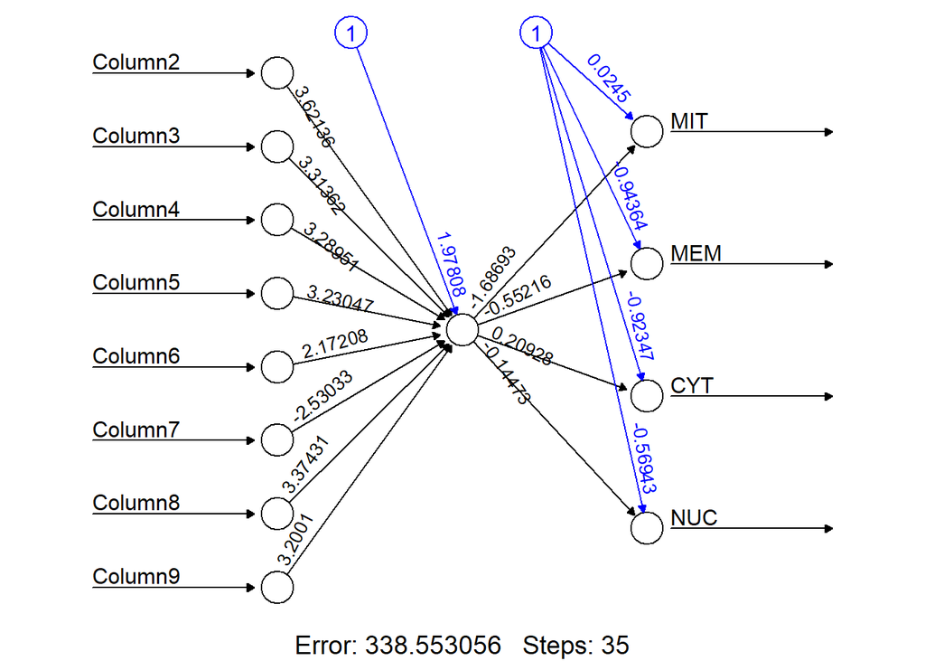

```r
data_n_ann$MIT <- data$class=="MIT"
data_n_ann$MEM <- data$class=="MEM"
data_n_ann$CYT <- data$class=="CYT"
data_n_ann$NUC <- data$class=="NUC"

xnam <- names(data_n_ann[1:8])

fmla <- as.formula(paste("MIT + MEM + CYT + NUC ~ ", paste(xnam, collapse= "+")))

data.train.n_ann<-data.train.n
data.train.n_ann$MIT <- data.train$class=="MIT"
data.train.n_ann$MEM <- data.train$class=="MEM"
data.train.n_ann$CYT <- data.train$class=="CYT"
data.train.n_ann$NUC <- data.train$class=="NUC"

data.test.n_ann<-data.test.n
data.test.n_ann$MIT <- data.test$class=="MIT"
data.test.n_ann$MEM <- data.test$class=="MEM"
data.test.n_ann$CYT <- data.test$class=="CYT"
data.test.n_ann$NUC <- data.test$class=="NUC"

data_model_1 <- neuralnet(fmla,
                          data = data.train.n_ann,
                          hidden=1,linear.output=FALSE)
plot(data_model_1, rep='best')
```

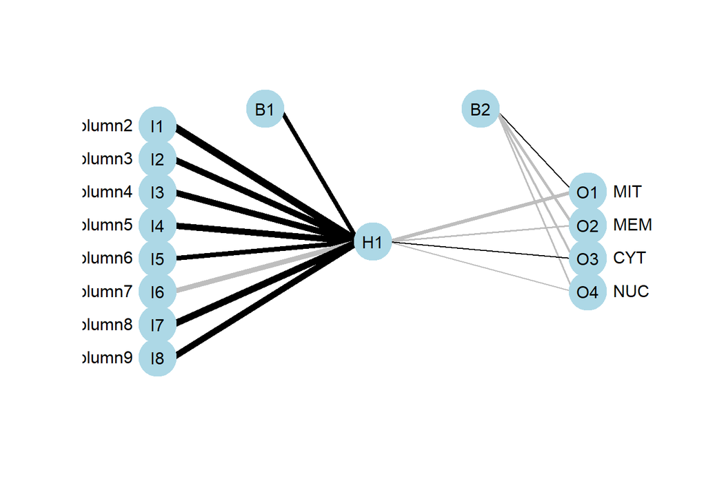

```r
library(NeuralNetTools)
plotnet(data_model_1, prune_col = "lightblue")
```

### 2.3.1 Evaluacion ANN

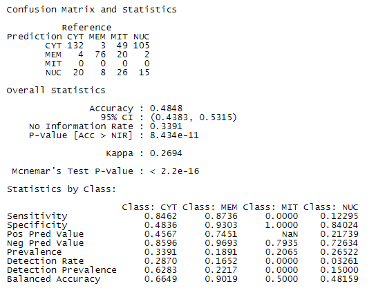

## 2.4 SVA

```r
library(kernlab)
data.test$class<-as.factor(data.test$class)
data.train$class<-as.factor(data.train$class)
sva <- ksvm(class ~ ., data = data.train)
sva
```

```
## Support Vector Machine object of class "ksvm"
##
## SV type: C-svc  (classification)
##  parameter : cost C = 1
##
## Gaussian Radial Basis kernel function.
##  Hyperparameter : sigma =  0.163893091033647
##
## Number of Support Vectors : 707
##
## Objective Function Value : -78.3736 -185.4227 -412.089 -65.6441 -97.4976 -170.4494
## Training error : 0.312634
```

```r
sva_predictions <- predict(sva, data.test)
```

### 2.4.1 Evaluacion SVA

```r
matrizsva<-confusionMatrix(sva_predictions, data.test$class)
matrizsva
```

```
## Confusion Matrix and Statistics
##
##           Reference
## Prediction CYT MEM MIT NUC
##        CYT 105   2  22  48
##        MEM   5  77  10   2
##        MIT   9   1  58   9
##        NUC  37   7   5  63
##
## Overall Statistics
##
##                Accuracy : 0.6587
##                  95% CI : (0.6134, 0.702)
##     No Information Rate : 0.3391
##     P-Value [Acc > NIR] : < 2.2e-16
##
##                   Kappa : 0.5336
##
##  Mcnemar's Test P-Value : 0.003474
##
## Statistics by Class:
##
##                      Class: CYT Class: MEM Class: MIT Class: NUC
## Sensitivity              0.6731     0.8851     0.6105     0.5164
## Specificity              0.7632     0.9544     0.9479     0.8550
## Pos Pred Value           0.5932     0.8191     0.7532     0.5625
## Neg Pred Value           0.8198     0.9727     0.9034     0.8305
## Prevalence               0.3391     0.1891     0.2065     0.2652
## Detection Rate           0.2283     0.1674     0.1261     0.1370
## Detection Prevalence     0.3848     0.2043     0.1674     0.2435
## Balanced Accuracy        0.7181     0.9197     0.7792     0.6857
```

## 2.5 Arbol

```r
library(C50)
data.train$class<-as.factor(data.train$class)
modelo<- C5.0(data.train[,-9], data.train$class)
modelo_pred<-predict(modelo, data.test)
```

### 2.5.1 Evaluacion C5

```r
matrizC5<-confusionMatrix(modelo_pred, data.test$class)
matrizC5
```

```
## Confusion Matrix and Statistics
##
##           Reference
## Prediction CYT MEM MIT NUC
##        CYT  77   4  19  42
##        MEM   2  76  12   3
##        MIT  22   1  53  16
##        NUC  55   6  11  61
##
## Overall Statistics
##
##                Accuracy : 0.5804
##                  95% CI : (0.5339, 0.626)
##     No Information Rate : 0.3391
##     P-Value [Acc > NIR] : < 2e-16
##
##                   Kappa : 0.4323
##
##  Mcnemar's Test P-Value : 0.03122
##
## Statistics by Class:
##
##                      Class: CYT Class: MEM Class: MIT Class: NUC
## Sensitivity              0.4936     0.8736     0.5579     0.5000
## Specificity              0.7862     0.9544     0.8932     0.7870
## Pos Pred Value           0.5423     0.8172     0.5761     0.4586
## Neg Pred Value           0.7516     0.9700     0.8859     0.8135
## Prevalence               0.3391     0.1891     0.2065     0.2652
## Detection Rate           0.1674     0.1652     0.1152     0.1326
## Detection Prevalence     0.3087     0.2022     0.2000     0.2891
## Balanced Accuracy        0.6399     0.9140     0.7255     0.6435
```

```r
modelo_boost<- C5.0(data.train[,-9], data.train$class, trials = 10)
modelo_pred_boost<-predict(modelo_boost, data.test)
```

```r
matriz_boost<-confusionMatrix(modelo_pred_boost, data.test$class)
matriz_boost
```

```
## Confusion Matrix and Statistics
##
##           Reference
## Prediction CYT MEM MIT NUC
##        CYT  73   1  22  37
##        MEM   5  79  10   4
##        MIT  23   2  57  11
##        NUC  55   5   6  70
##
## Overall Statistics
##
##                Accuracy : 0.6065
##                  95% CI : (0.5602, 0.6514)
##     No Information Rate : 0.3391
##     P-Value [Acc > NIR] : < 2e-16
##
##                   Kappa : 0.4693
##
##  Mcnemar's Test P-Value : 0.04108
##
## Statistics by Class:
##
##                      Class: CYT Class: MEM Class: MIT Class: NUC
## Sensitivity              0.4679     0.9080     0.6000     0.5738
## Specificity              0.8026     0.9491     0.9014     0.8047
## Pos Pred Value           0.5489     0.8061     0.6129     0.5147
## Neg Pred Value           0.7462     0.9779     0.8965     0.8395
## Prevalence               0.3391     0.1891     0.2065     0.2652
## Detection Rate           0.1587     0.1717     0.1239     0.1522
## Detection Prevalence     0.2891     0.2130     0.2022     0.2957
## Balanced Accuracy        0.6353     0.9286     0.7507     0.6893
```

# 3 Conclusiones

El aprendizaje automático es el proceso adaptativo que hace que las computadoras mejoren a partir de la experiencia, por ejemplo y por analogía. Por lo que es una disciplina de metodologías que proporciona, de una forma u otra, capacidades de procesamiento de información inteligente para el manejo de la vida real. La bioinformática es una de las aplicaciones del aprendizaje automático. La bioinformática es la ciencia interdisciplinaria de interpretar datos biológicos utilizando tecnología de la información e informática.

El aprendizaje automático (ML) se centra en el aprendizaje a partir de un conjunto de datos. El aprendizaje automático incluye la velocidad de aprendizaje, la garantía de convergencia y cómo se pueden aprender los datos de forma incremental. Por lo general, nos referimos a métodos como redes neuronales artificiales (ANN), algoritmos genéticos (GA) y sistemas difusos junto con métodos híbridos que incluyen una combinación de algunos de estos métodos. Uno de los principales problemas es clasificar los genes normales y los genes inválidos que están infectados por algún tipo de enfermedad.

En la investigación genómica, la clasificación de secuencias de ADN en categorías existentes se usa para aprender las funciones de una nueva proteína. Entonces, es importante identificar esos genes y clasificarlos. Para identificar los genes infectados y los genes normales con el uso de métodos de clasificación aquí usamos las técnicas de aprendizaje automático.

La clasificación de secuencias de ADN en categorías existentes se utiliza para aprender las funciones de una nueva proteína. Entonces, es importante identificar esos genes y clasificarlos. Para identificar los genes infectados y los genes normales con el uso de métodos de clasificación aquí usamos las técnicas de aprendizaje automático.

En este sentido, se utilizaron las siguientes tres etapas: 1) transformación de los datos (en caso necesario) 2) Entrenar el modelo 3) Predicción y Evaluación del algoritmo. Para la evaluación final del trabajo, y para comparar la **performance** de cada modelo, se usó una *confusionMatrix()* la cual brinda una idea de **Accuracy**.

**Por ende, el modelo que seleccionaría, no solo por ser el de mayor accurancy, sino por sus fortalezas y debilidades, es SVA**.

# Referencias

Li, Haoyang, Shuye Tian, Yu Li, Qiming Fang, Renbo Tan, Yijie Pan, Chao Huang, Ying Xu, and Xin Gao. 2020. “Modern deep learning in bioinformatics.” *Journal of Molecular Cell Biology* 12 (11): 823–27. https://doi.org/10.1093/jmcb/mjaa030.

Prompramote, Supawan, Yan Chen, and Yi-Ping Phoebe Chen. 2005. “Machine Learning in Bioinformatics.” In *Bioinformatics Technologies*, edited by Yi-Ping Phoebe Chen, 117–53. Berlin, Heidelberg: Springer Berlin Heidelberg. https://doi.org/10.1007/3-540-26888-X_5.

Shastry, K. Aditya, and H. A. Sanjay. 2020. “Machine Learning for Bioinformatics.” In *Statistical Modelling and Machine Learning Principles for Bioinformatics Techniques, Tools, and Applications*, edited by K. G. Srinivasa, G. M. Siddesh, and S. R. Manisekhar, 25–39. Singapore: Springer Singapore. https://doi.org/10.1007/978-981-15-2445-5_3.

Stathakis, D. 2009. “How Many Hidden Layers and Nodes?” *International Journal of Remote Sensing* 30 (8): 2133–47. https://doi.org/10.1080/01431160802549278.

Trenn, Stephan. 2008. “Multilayer Perceptrons: Approximation Order and Necessary Number of Hidden Units.” *IEEE Transactions on Neural Networks / a Publication of the IEEE Neural Networks Council* 19 (June): 836–44. https://doi.org/10.1109/TNN.2007.912306.